# Housing price prediction for King county, WA

Joseph Juhn (jjuhn2), Olga Scrivner (olgas2), Hardik Naik (hardikn2), Marie Biscarrat (biscarr1)

# Team

- Joseph Juhn (jjuhn2)
- Olga Scrivner (olgas2)
- Hardik Naik (hardikn2)
- Marie Biscarrat (biscarr1)

# Introduction

We are looking to study how house price ($) can be predicted using various factors, such as the number of bedrooms, view, location, condition etc. This is one of the essential questions asked by almost every family when they decide to buy a new house. The goal of our model is to help a buyer identify a house price based on their preferred option.

- Multiple linear regression
- Dummy variables
- Interaction
- Residual diagnostics
- Outlier diagnostics
- Logarithmic Transformations
- Model selection

# Data Preparation

## Packages and needed functions

First, we defined any functions that would facilitate the statistical analysis of our data and the different models we fitted.

```r
#Functions
calc_test_rmse = function(model,log=FALSE){
  predictions = ifelse(log, exp(predict(model, house_tst)), predict(model, house_tst))
  rmse_test = sqrt(mean((house_tst$price - predictions) ^ 2))
  dollar(rmse_test)
}

diagnostics = function(model, pcol = "grey", lcol = "dodgerblue", alpha = 0.05, plotit = TRUE,
                       testit = FALSE) {

  if (plotit == TRUE) {
    par(mfrow = c(1, 2))

    plot(fitted(model) , resid(model), col = pcol, pch = 20,
         xlab = "Fitted", ylab = "Residuals", main = "Fitted vs Residuals")
    abline(h = 0, col = lcol, lwd = 2)

    qqnorm(resid(model), col = pcol, pch = 20)
    qqline(resid(model), col = lcol, lwd = 2)
  }

  if (testit == TRUE) {
    p_val = shapiro.test(resid(model))$p.value
    decision = ifelse(p_val < alpha, "Reject", "Fail to Reject")
    list(p_val = p_val, decision = decision)
  }
}

calc_loocv_rmse = function(model) {
  sqrt(mean((resid(model) / (1 - hatvalues(model))) ^ 2))
}
```

## First look at the data

After loading the data and removing NULL values, we first tried to fit a linear model with Price as a response and all the other variables as predictors. This was done to get an idea of what type of values (R$^2$, RMSE) we would get without doing any data processing. We noticed that, aside from the `Date`, none of the variables were factors.

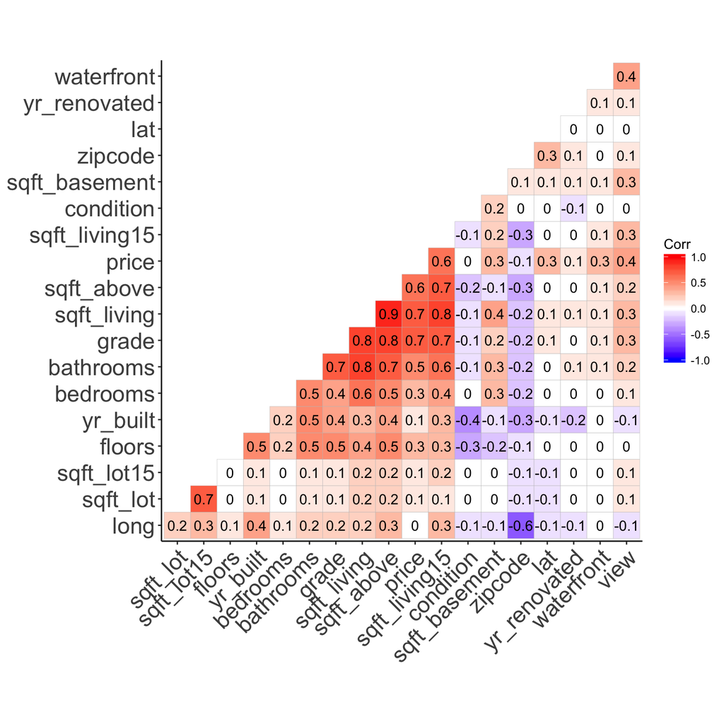

```r
set.seed(5)
house_data_raw = read.table("kc_house_data.csv", header = T, sep = ",")
house_data_raw = na.omit(house_data_raw)

corr <- round(cor(house_data_raw[-c(1,2)]), 1)
ggcorrplot(corr,method="square", hc.order = TRUE, type = "lower", lab = TRUE,ggtheme = ggplot2::theme_classic, tl.cex = 18)
```

```r
model_additive_basic = lm(price ~ . , data = house_data_raw)
summary(model_additive_basic)$adj.r.squared
```

```
## [1] 0.7018736
```

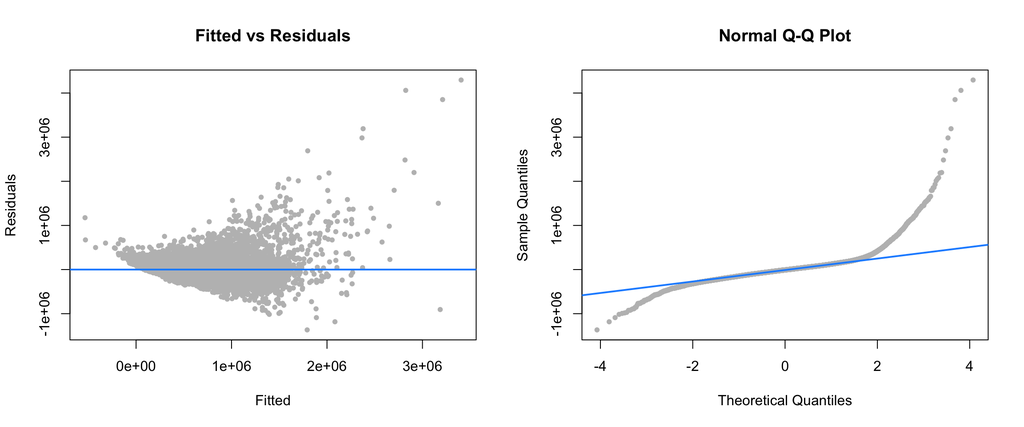

```r
diagnostics(model_additive_basic)
```

While $R^2_{adj}$ was good the fitted vs Residual and Q-Q plots shows that a lot of modifications needs to be done to the model and data.

After looking at the data and the model, we realized that the number of bathrooms and rooms were fixed and that the variable `bathrooms` could not be any value when using this model to predict the price of a house in King County. Therefore, after some data manipulation, `bedrooms` and `bathrooms` were transformed into a factor variable. The variables `view`, `floors`, `waterfront`, `condition` and `grade` were also transformed into factors because they could only be a specific value or characterization.

## Data Manipulation

### Bathroom

We believed that .25 and .75 bathrooms were too precise, and would give us a huge number of levels, so we decided to round to the lowest integer when the number of bathrooms when there was a value with .25 and to round to the lower .5 for a value with .75. We always lowered the number of bathrooms as having more bathrooms than advertised or recorded is not an issue whereas having a larger number of bathrooms than the reality might be a problem for those who were looking for that number of bathrooms. After looking at the distribution of the data, we see that the majority of the houses have 3.5 bathrooms or less. To avoid having a test data with a level that is not present in the train data or vice versa, any bathroom with more than 3.5 bathrooms were set to the same category `3.5+`.

### Floors

A similar rounding process was done for the number of floors, as we believed the half levels were a precision that was not needed and that would increase the number of levels unnecessarily.

### Bedroom

For the number of bedrooms, we looked at the distribution of the data in a histogram and we saw that the majority of the data fell between 0 and 6. Houses with more than 6 rooms were rare. Therefore, we grouped the houses with more than 6 bedrooms into one category `6+`. This change also avoided some factors not being in the train or test data.

### Grade

The grade value was also transformed into groups to avoid having too many variables in the model. According to the King county info website, the grade can be separated into 4 categories: `Inferior`, `Low`, `Average` and `High`.

After transforming some of the data, we looked at which variables could be removed as it would complicate the model if treated as a categorical variable, but would not make sense as a numerical value. This was the case for `id`, `date` and `zipcode`. We also removed the Year built and Renovation variable as those were transformed into `age` and were now unnecessary and bedroom and bathroom as those were reassigned. We also decided to remove `sqft_basement` as there was another jump in the data with houses without basement having a 0 and it could not be modified easily.

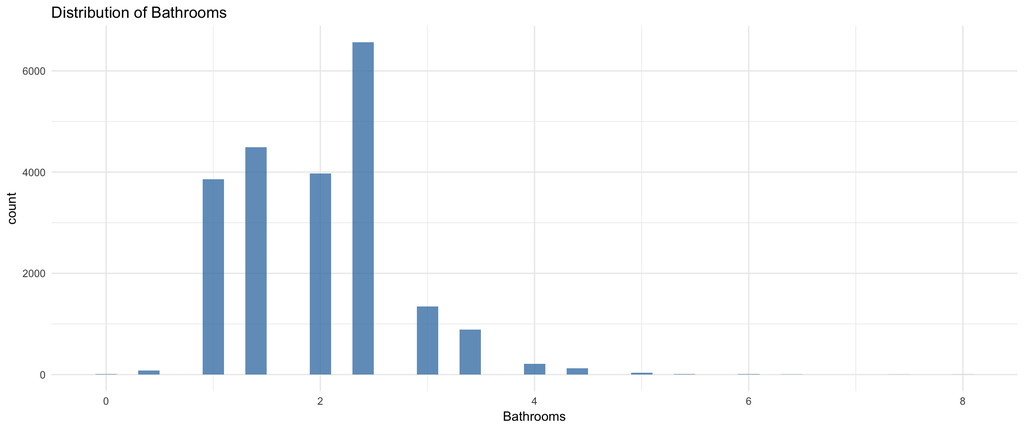

```r
house_data_base = house_data_raw

house_data_base$bathrooms = mapvalues(house_data_base$bathrooms, from = c(0.75, 1.25,  1.75, 2.25, 2.75, 3.25, 3.75, 4.25, 4.75, 5.25, 5.75, 6.25, 6.75, 7.75), to = c(0.5, 1, 1.5, 2, 2.5, 3, 3.5, 4, 4.5, 5, 5.5, 6, 6.5, 7.5))

ggplot(house_data_base, aes(bathrooms)) +geom_histogram(binwidth=0.2, fill="steelblue", alpha=I(0.8)) + theme_minimal() + labs(title="Distribution of Bathrooms", x="Bathrooms")
```

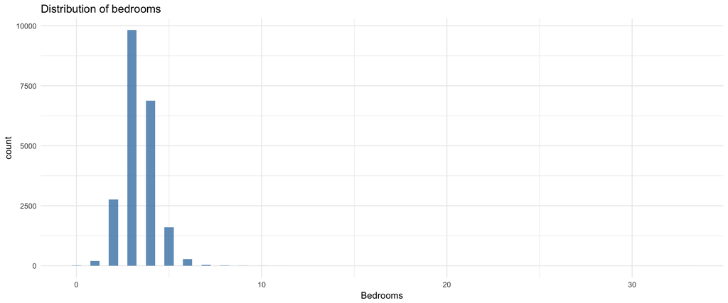

```r
house_data_base$bathrooms_comp = ifelse(house_data_base$bathrooms>3.5,"3.5 +", as.character(house_data_base$bathrooms))

house_data_base$floors = mapvalues(house_data_base$floors, from = c(1.5, 2.5, 3.5), to = c(1, 2, 3))

ggplot(house_data_base, aes(bedrooms)) +geom_histogram(binwidth=0.5, fill="steelblue", alpha=I(0.8)) + theme_minimal() + labs(title="Distribution of bedrooms", x="Bedrooms")
```

```r
house_data_base$bedrooms_comp = ifelse(house_data_base$bedrooms>6,"6 +", as.character(house_data_base$bedrooms))

house_data_base$age = ifelse(house_data_base$yr_renovated == 0, 2015 - house_data_base$yr_built, 2015 - house_data_base$yr_renovated)

house_data_base$grade = mapvalues(house_data_base$grade,
                                  from = c(1,3,4,5,6,7,8,9,10,11,12,13),
                                  to = c("Inferior","Inferior","Inferior","Inferior","Low","Average","Average","Average","High","High","High","High"))


house_data_base$bedrooms_comp = as.factor(house_data_base$bedrooms_comp)
house_data_base$bathrooms_comp = as.factor(house_data_base$bathrooms_comp)
house_data_base$floors = as.factor(house_data_base$floors)
house_data_base$view = as.factor(house_data_base$view)
house_data_base$waterfront = as.factor(house_data_base$waterfront)
house_data_base$condition = as.factor(house_data_base$condition)
house_data_base$grade = as.factor(house_data_base$grade)

# Remove the variables
remove = c("id","date","zipcode", "bedrooms", "bathrooms","yr_built", "yr_renovated","sqft_basement")
house_data = house_data_base[ , !(names(house_data_base) %in% remove)]

# train and test split
house_idx = sample(nrow(house_data), 5000)
house_trn = house_data[-house_idx, ]
house_tst = house_data[house_idx, ]
```

Finally, we split data into a training set (16613) and testing set (5000).

# Analysis of Data and Interpretation of Results

## Additive Model

Using the train data set, an additive model with price as a response and all other variables is fit using linear regression.

```r
model_additive_test = lm(price ~ . , data = house_trn)
summary(model_additive_test)$adj.r.squared
```

```
## [1] 0.6883469
```

```r
calc_test_rmse(model_additive_test, log=FALSE)
```

```
## [1] "$355,439"
```

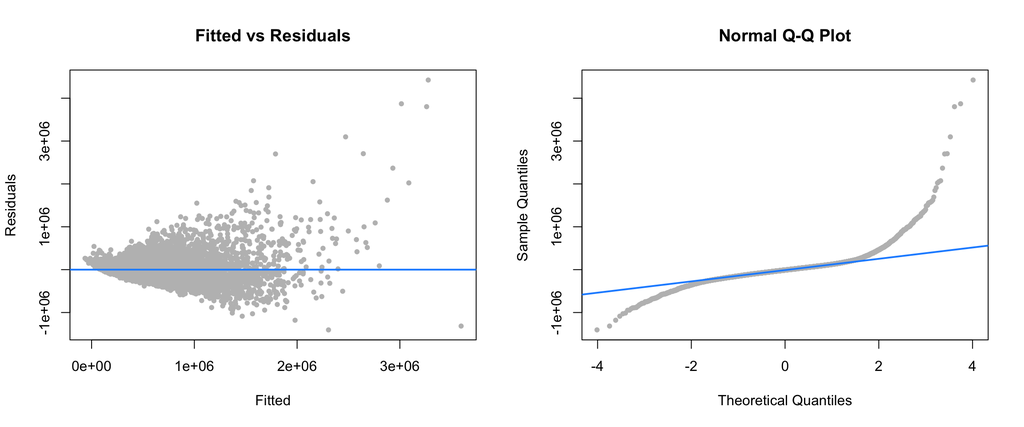

```r
diagnostics(model_additive_test)
```

Looking at the fitted-residual plot and the Q-Q plot, we reject the equal variance and the normality assumption.

```r
 boxcox(model_additive_test, lambda = seq(-0.1, 0.1, length = 20))
```

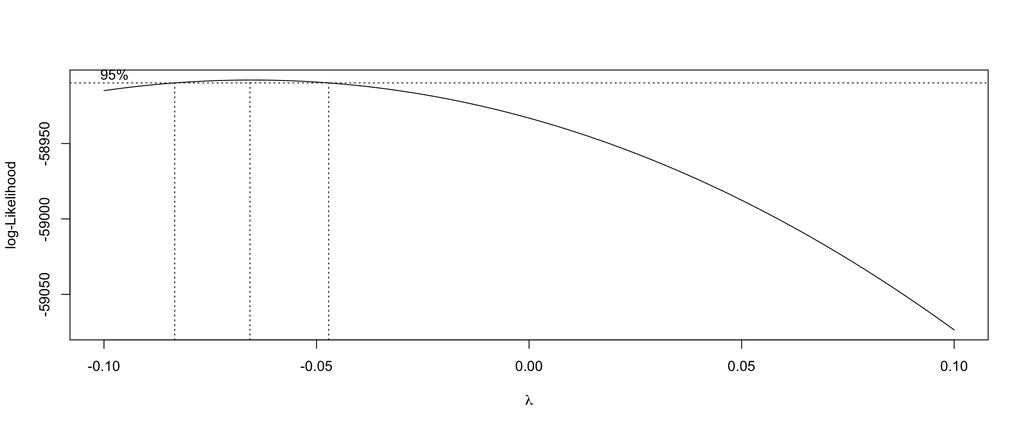

A box cox test is done and indicates having lambda closer to 0 would benefit the model. Although 0 is out of the 95 % confidence interval, it is pretty close and we didn’t want to use fractional value. Having $\lambda=0$ suggests to use log trandormation on response variable `price`.

## Response transformation: Logged Response

```r
model_additive_log = lm(log(price) ~ . , data = house_trn)
summary(model_additive_log)$adj.r.squared
```

```
## [1] 0.7390135
```

```r
calc_test_rmse(model_additive_log, log=TRUE)
```

```
## [1] "$355,327"
```

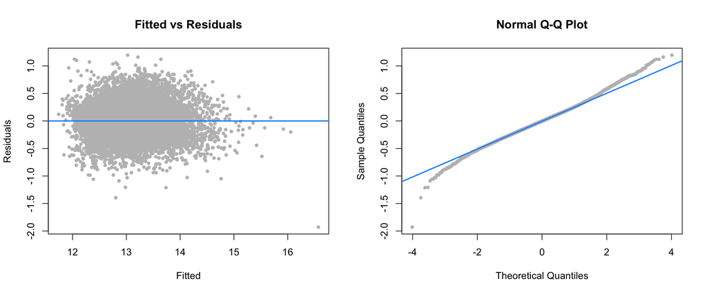

```r
diagnostics(model_additive_log)
```

## Collinearity

```r
car::vif(model_additive_log)
```

```
##                     GVIF Df GVIF^(1/(2*Df))
## sqft_living     8.303715  1        2.881617
## sqft_lot        2.081425  1        1.442715
## floors          2.815305  2        1.295333
## waterfront      1.572868  1        1.254140
## view            1.882918  4        1.082316
## condition       1.428698  4        1.045605
## grade           2.707834  3        1.180602
## sqft_above      7.173565  1        2.678351
## lat             1.134910  1        1.065322
## long            1.505742  1        1.227087
## sqft_living15   2.798274  1        1.672804
## sqft_lot15      2.120213  1        1.456095
## bathrooms_comp 10.573780  8        1.158816
## bedrooms_comp   4.318794  7        1.110154
## age             2.495974  1        1.579865
```

We look at the collinearity of all the variables used to fit the model. It is common practice to say that, if the VIF is greater than 5, then there is collinearity. Here we see that `bathrooms_comp`, `sqft_living` and `sqft_above` have VIFs greater than 5, therefore there is collinearity. We decide to keep `sqft_living` as we believe it is collinear to `sqft_above` and we believe it is an important variable that can affect the price.

## Small Additive Model

We fit an additive model with `log(price)` as the response and all variables except `bathroom_com` and `sqft_above` as predictors.

```r
model_additive_small = lm(log(price) ~ . -bathrooms_comp -sqft_above, data = house_trn)

summary(model_additive_small)$adj.r.squared
```

```
## [1] 0.735062
```

```r
calc_test_rmse(model_additive_small, log=TRUE)
```

```
## [1] "$367,117"
```

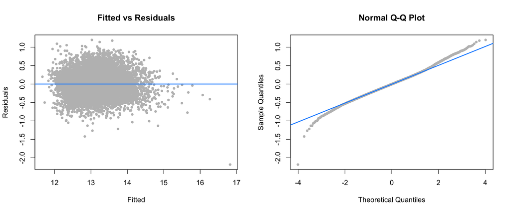

```r
diagnostics(model_additive_small)
```

```r
car::vif(model_additive_small)
```

```
##                   GVIF Df GVIF^(1/(2*Df))
## sqft_living   3.891689  1        1.972736
## sqft_lot      2.074647  1        1.440364
## floors        1.986320  2        1.187168
## waterfront    1.565050  1        1.251020
## view          1.827026  4        1.078247
## condition     1.383500  4        1.041412
## grade         2.213329  3        1.141583
## lat           1.125291  1        1.060798
## long          1.451864  1        1.204933
## sqft_living15 2.693292  1        1.641125
## sqft_lot15    2.115816  1        1.454585
## bedrooms_comp 1.988706  7        1.050332
## age           2.243810  1        1.497935
```

## BIC backward model Selection

```r
model_bic = step(model_additive_small,trace=0, k= log(length(resid(model_additive_small))))
summary(model_bic)$adj.r.squared
```

```
## [1] 0.7349632
```

```r
calc_test_rmse(model_bic, log=TRUE)
```

```
## [1] "$367,072"
```

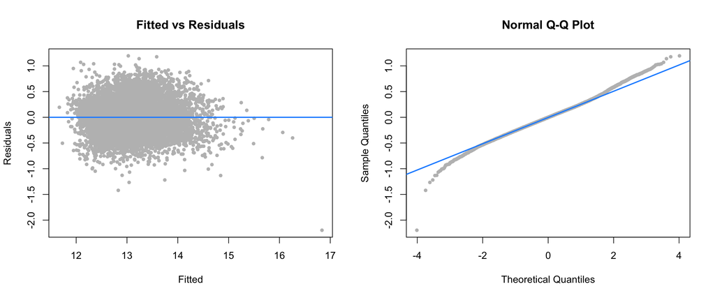

```r
diagnostics(model_bic)
```

Using the small additive logged model, we perform a backwards step BIC model selection.

```r
# removing influential data for normality
cd = cooks.distance(model_bic)
model_bic_add_cook = lm(log(price) ~ sqft_living + sqft_lot + floors + waterfront +
                          view + condition + grade + lat + long + sqft_living15 + age,
                        data = house_trn, subset = cd <= 4/length(resid(model_bic)))

summary(model_bic_add_cook)$adj.r.squared
```

```
## [1] 0.7535101
```

```r
calc_test_rmse(model_bic_add_cook, log=TRUE)
```

```
## [1] "$368,862"
```

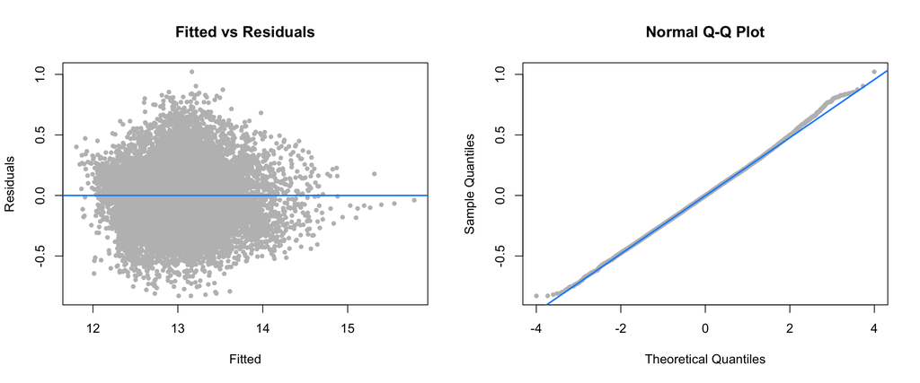

```r
diagnostics(model_bic_add_cook)
```

From the Fitted vs Residuals plot, we also observe that for the vast majority of data the equal variance assumption was satisfied.

## Interactive modeling and BIC

Next, we want to build an interaction model and test whether there is a relation in which the outcome of one independent variable depends on the value of another independent variable.

```r
big_model_interactive = lm(log(price) ~ (sqft_living + sqft_lot + waterfront + view  + lat + long +                             sqft_living15 + age + grade + condition +  floors)^2 , data = house_trn)
summary(big_model_interactive)$adj.r.squared
```

```
## [1] 0.7673042
```

The adjusted $R^2$ is 0.7673042. Next we perform the BIC backwards step model selection.

```r
#BIC search
k = log(length(resid(big_model_interactive)))
model_int_bic = step(big_model_interactive, k= k, trace = 0)

#different checks
summary(model_int_bic)$adj.r.squared
```

```
## [1] 0.7639216
```

```r
calc_test_rmse(model_int_bic, log=TRUE)
```

```
## [1] "$359,480"
```

```r
car::vif(model_int_bic)
```

```
##                                 GVIF Df GVIF^(1/(2*Df))
## sqft_living             2.507428e+06  1     1583.486174
## sqft_lot                1.135133e+05  1      336.917324
## waterfront              1.132750e+06  1     1064.307062
## view                    2.526840e+03  4        2.662700
## lat                     1.101077e+06  1     1049.322334
## long                    1.721124e+05  1      414.864339
## sqft_living15           2.554026e+06  1     1598.131996
## age                     2.293241e+06  1     1514.345034
## grade                   7.960779e+17  3      962.703600
## condition               4.600442e+05  4        5.103286
## floors                  5.991659e+12  2     1564.540379
## sqft_living:view        2.644401e+03  4        2.677879
## sqft_living:long        2.505685e+06  1     1582.935548
## sqft_living:age         1.481599e+01  1        3.849155
## sqft_lot:lat            1.135141e+05  1      336.918606
## sqft_lot:sqft_living15  2.030579e+01  1        4.506195
## sqft_lot:age            7.889110e+00  1        2.808756
## sqft_lot:grade          1.217258e+01  3        1.516691
## waterfront:long         1.132605e+06  1     1064.238971
## lat:long                1.396941e+06  1     1181.922594
## lat:age                 3.407127e+05  1      583.705965
## lat:floors              1.707187e+11  2      642.791711
## long:sqft_living15      2.547663e+06  1     1596.139968
## long:age                2.387670e+06  1     1545.208610
## long:grade              7.931296e+17  3      962.108446
## long:floors             5.584567e+12  2     1537.260195
## sqft_living15:age       3.185489e+01  1        5.644014
## sqft_living15:grade     6.836043e+03  3        4.356464
## sqft_living15:condition 2.905390e+06  4        6.425406
## sqft_living15:floors    3.822341e+02  2        4.421629
## age:condition           6.310649e+05  4        5.308958
## age:floors              8.188945e+00  2        1.691636
```

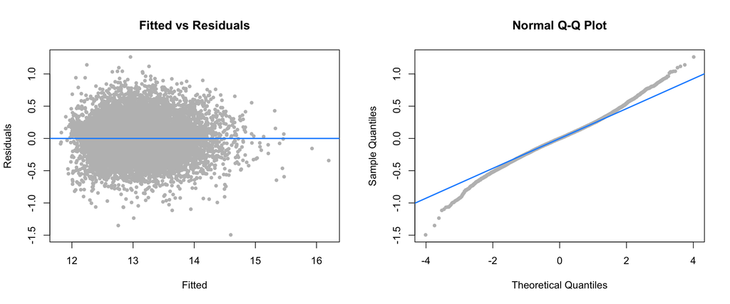

```r
diagnostics(model_int_bic)
```

```r
#removing influential data to improve normality
cd = cooks.distance(model_int_bic)
model_bic_int_cook = lm(log(price) ~ sqft_living + sqft_lot + waterfront +
                          view + lat + long + sqft_living15 + age + grade + condition +
                          floors + sqft_living:sqft_lot + sqft_living:view + sqft_living:long +
                          sqft_living:age + sqft_lot:lat + sqft_lot:sqft_living15 +
                          sqft_lot:age + waterfront:long + lat:long + lat:age + lat:floors +
                          long:sqft_living15 + long:age + long:grade + long:floors +
                          sqft_living15:age + sqft_living15:grade + sqft_living15:condition +
                          sqft_living15:floors + age:grade + age:condition + age:floors,
                        data = house_trn, subset = cd <= 4/length(resid(model_int_bic)))

summary(model_bic_int_cook)$adj.r.squared
```

```
## [1] 0.7809612
```

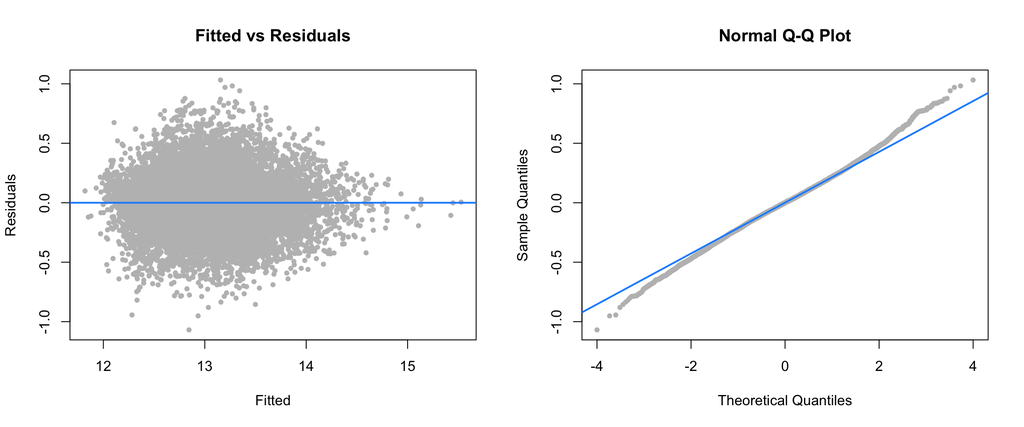

```r
diagnostics(model_bic_int_cook)
```

```r
calc_test_rmse(model_bic_int_cook, log=TRUE)
```

```
## [1] "$360,677"
```

# Discussion and Summary

The goal of this project was to identify the best model to predict house price using the methods discussed in class. This was done by trying to increase $R^2$ and lower $RMSE_{test}$, while satisfying the normality, linearity and equal variance assumptions.

log(price) ~ sqft_living + sqft_lot + floors + waterfront + view + condition + grade + lat + long + sqft_living15 + age

# Reference

http://info.kingcounty.gov/assessor/esales/Glossary.aspx?type=r [Accessed July 25, 2018].

House Sales in King County [Dataset] (2016) Kaggle. Available at: https://www.kaggle.com/harlfoxem/housesalesprediction [Accessed July 25, 2018].

# Additional Notes: Initial Proposal

Our initial research looked at Enrollment Rate across US Universities from IPEDS (https://nces.ed.gov/ipeds/use-the-data). We spent lot more time on data preparation and cleaning aspect initially. We evaluated additive and interactive models using a variety of techniques, and we improved our $R^2$ from 0.11 to 0.30. However, we were not sure that such a low score would be sufficient for the final project. We later discussed this with David Unger in office hour and got an approval for the switch.